# README

Author

James Day, a1820798

Published

March 16, 2024

The collaborator has provided raw data in movies.xlsx and would like to find which genre gives the best Christmas movies rating. To initially clean the data, rows without any genres recorded were removed and the data was restricted so that the title types were only movies (rather than tvMovies or videos). Movies with multiple genres were also split by genre into separate rows with duplicated ratings to ensure that only one genre corresponds to a rating. The modified dataset is given below.

```r
tar_load(movies_clean)
movies_clean
```

```
# A tibble: 1,499 × 3
   genres    average_rating christmas
   <chr>              <dbl> <lgl>
 1 Comedy               5.4 FALSE
 2 Drama                6   FALSE
 3 Romance              6   FALSE
 4 Comedy               6.3 FALSE
 5 Drama                6.3 FALSE
 6 Comedy               7.4 FALSE
 7 Comedy               6.1 FALSE
 8 Romance              6.1 FALSE
 9 Adventure            6.3 FALSE
10 Crime                6.3 FALSE
# ℹ 1,489 more rows
```

To distinguish the effect of genre on average_ratings when the movie was a Christmas movie, the dataset was further restricted to only include Christmas movies as follows.

```r
tar_load(movies_christmas)
movies_christmas
```

```
# A tibble: 1,139 × 3
   genres    average_rating christmas
   <chr>              <dbl> <lgl>
 1 Drama                7.5 TRUE
 2 Family               7.5 TRUE
 3 Fantasy              7.5 TRUE
 4 Comedy               7.4 TRUE
 5 Drama                7.4 TRUE
 6 Romance              7.4 TRUE
 7 Crime                6.5 TRUE
 8 Drama                6.5 TRUE
 9 Film-Noir            6.5 TRUE
10 Comedy               7.3 TRUE
# ℹ 1,129 more rows
```

Sorting by the mean average_rating across each genres, the following table was produced for Christmas movies.

```r
tar_read(christmas_tab)
```

| genres | mean_rating | median_rating | stdev_rating | num_movies |
| --- | --- | --- | --- | --- |
| Documentary | 7.11 | 7.20 | 1.05 | 15 |
| Music | 7.00 | 7.30 | 1.22 | 11 |
| Biography | 6.92 | 7.05 | 0.43 | 4 |
| Film-Noir | 6.50 | 6.50 | NA | 1 |
| War | 6.32 | 6.70 | 1.27 | 5 |
| Sci-Fi | 6.06 | 6.20 | 1.19 | 7 |
| Animation | 6.01 | 6.15 | 1.23 | 34 |
| Musical | 5.94 | 6.50 | 1.76 | 17 |
| Sport | 5.85 | 5.85 | 2.05 | 2 |
| Western | 5.80 | 5.70 | 0.46 | 3 |
| Drama | 5.77 | 5.90 | 1.22 | 210 |
| Adventure | 5.74 | 5.75 | 0.98 | 40 |
| History | 5.70 | 5.70 | 2.26 | 2 |
| Romance | 5.68 | 5.60 | 1.12 | 130 |
| Fantasy | 5.51 | 5.60 | 1.45 | 57 |
| Comedy | 5.50 | 5.50 | 1.34 | 293 |
| Family | 5.48 | 5.50 | 1.36 | 210 |
| Crime | 5.28 | 5.70 | 1.20 | 13 |
| Mystery | 5.28 | 5.00 | 1.84 | 11 |
| Thriller | 4.83 | 4.55 | 1.58 | 18 |
| Action | 4.81 | 5.10 | 2.06 | 13 |
| Horror | 4.64 | 4.60 | 1.45 | 43 |

Similarly, the following table was produced for all movies.

```r
tar_read(movies_tab)
```

| genres | mean_rating | median_rating | stdev_rating | num_movies |
| --- | --- | --- | --- | --- |
| Documentary | 7.25 | 7.30 | 0.92 | 22 |
| Film-Noir | 6.90 | 6.90 | 0.57 | 2 |
| Biography | 6.80 | 7.00 | 0.47 | 5 |
| Music | 6.76 | 6.70 | 1.08 | 17 |
| War | 6.27 | 6.60 | 1.15 | 6 |
| Animation | 6.05 | 6.20 | 1.24 | 35 |
| Musical | 5.94 | 6.05 | 1.38 | 32 |
| History | 5.90 | 6.10 | 1.48 | 4 |
| Drama | 5.88 | 6.00 | 1.18 | 282 |
| Adventure | 5.87 | 6.00 | 1.09 | 49 |
| Sport | 5.85 | 5.85 | 2.05 | 2 |
| Romance | 5.83 | 5.80 | 1.16 | 183 |
| Crime | 5.77 | 5.90 | 1.23 | 35 |
| Western | 5.74 | 5.70 | 0.69 | 5 |
| Comedy | 5.66 | 5.70 | 1.32 | 402 |
| Sci-Fi | 5.64 | 5.70 | 1.62 | 8 |
| Family | 5.55 | 5.60 | 1.40 | 234 |
| Fantasy | 5.52 | 5.60 | 1.41 | 62 |
| Mystery | 5.30 | 5.30 | 1.42 | 20 |
| Action | 5.23 | 5.55 | 1.79 | 20 |
| Thriller | 4.95 | 5.10 | 1.52 | 26 |
| Horror | 4.66 | 4.55 | 1.50 | 48 |

We can see that the top five genres for both tables are the same, albeit in slightly different orders: Documentary, Music, Biography, Film-Noir, and War. Since there are only two Film-Noir movies in the entire dataset and one in the Christmas movies dataset, we can omit Film-Noir from the table so that the fifth highest rated genre is Sci-Fi for Christmas movies and Animation for all movies. Sci-Fi is one of the few genres to drop significantly in the rankings when relaxing the restriction from Christmas to all movies. It would be desirable to quantitatively clarify the effects, if any, of Christmas movies on the relationship between genres and movie ratings.

Linear models of increasingly complexity were fit to the unrestricted dataset ‘movies_clean’. Put simply, MNull assumes no relationship between a movie’s genres and its average_rating. M1 models the average_rating as dependent on the movie genre but not on whether or not it is a Christmas movie. M2 assumes that a Christmas movie will affect all movie ratings equally, regardless of genre. M3 assumes that the effect of a movie’s genre on its average_rating is different for Christmas and non-Christmas movies.

```r
tar_load(MNull)
summary(MNull)
```

```
Call:
lm(formula = average_rating ~ 1, data = m_data)

Residuals:
    Min      1Q  Median      3Q     Max
-4.4155 -0.8155  0.0845  0.7845  4.1845

Coefficients:
            Estimate Std. Error t value Pr(>|t|)
(Intercept)  5.71548    0.03436   166.3   <2e-16 ***
---
Signif. codes:  0 '***' 0.001 '**' 0.01 '*' 0.05 '.' 0.1 ' ' 1

Residual standard error: 1.33 on 1498 degrees of freedom
```

```r
tar_load(M1)
summary(M1)
```

```
Call:
lm(formula = average_rating ~ genres, data = m_data)

Residuals:
    Min      1Q  Median      3Q     Max
-4.3634 -0.7634  0.0366  0.7774  4.3491

Coefficients:
                  Estimate Std. Error t value Pr(>|t|)
(Intercept)         5.2300     0.2889  18.101  < 2e-16 ***
genresAdventure     0.6353     0.3429   1.853 0.064097 .
genresAnimation     0.8243     0.3622   2.276 0.023004 *
genresBiography     1.5700     0.6461   2.430 0.015217 *
genresComedy        0.4334     0.2960   1.464 0.143377
genresCrime         0.5414     0.3622   1.495 0.135176
genresDocumentary   2.0246     0.3992   5.071 4.45e-07 ***
genresDrama         0.6512     0.2990   2.178 0.029573 *
genresFamily        0.3209     0.3010   1.066 0.286668
genresFantasy       0.2926     0.3323   0.880 0.378732
genresFilm-Noir     1.6700     0.9583   1.743 0.081600 .
genresHistory       0.6700     0.7077   0.947 0.343967
genresHorror       -0.5696     0.3439  -1.656 0.097890 .
genresMusic         1.5288     0.4263   3.587 0.000346 ***
genresMusical       0.7106     0.3683   1.929 0.053880 .
genresMystery       0.0750     0.4086   0.184 0.854396
genresRomance       0.6028     0.3043   1.981 0.047801 *
genresSci-Fi        0.4075     0.5405   0.754 0.451056
genresSport         0.6200     0.9583   0.647 0.517746
genresThriller     -0.2762     0.3843  -0.719 0.472536
genresWar           1.0367     0.6015   1.724 0.084999 .
genresWestern       0.5100     0.6461   0.789 0.430023
---
Signif. codes:  0 '***' 0.001 '**' 0.01 '*' 0.05 '.' 0.1 ' ' 1

Residual standard error: 1.292 on 1477 degrees of freedom
Multiple R-squared:  0.06971,   Adjusted R-squared:  0.05648
F-statistic:  5.27 on 21 and 1477 DF,  p-value: 1.38e-13
```

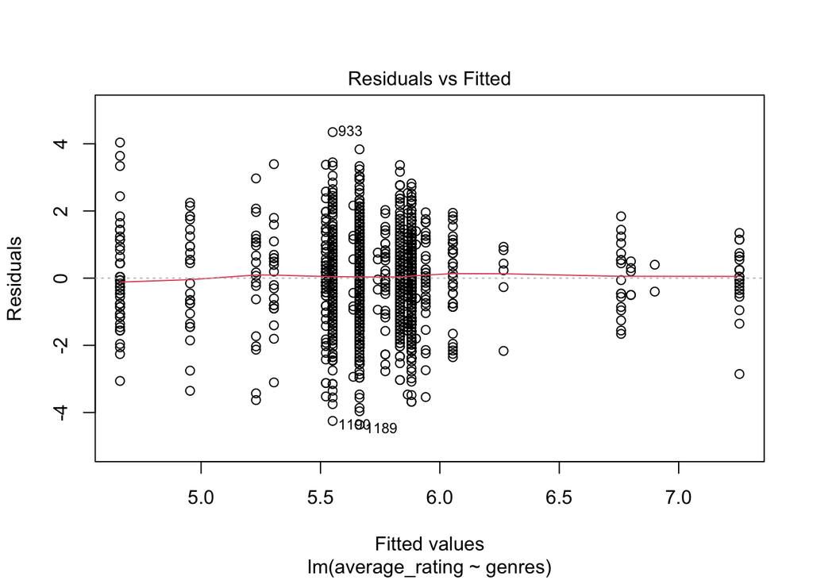

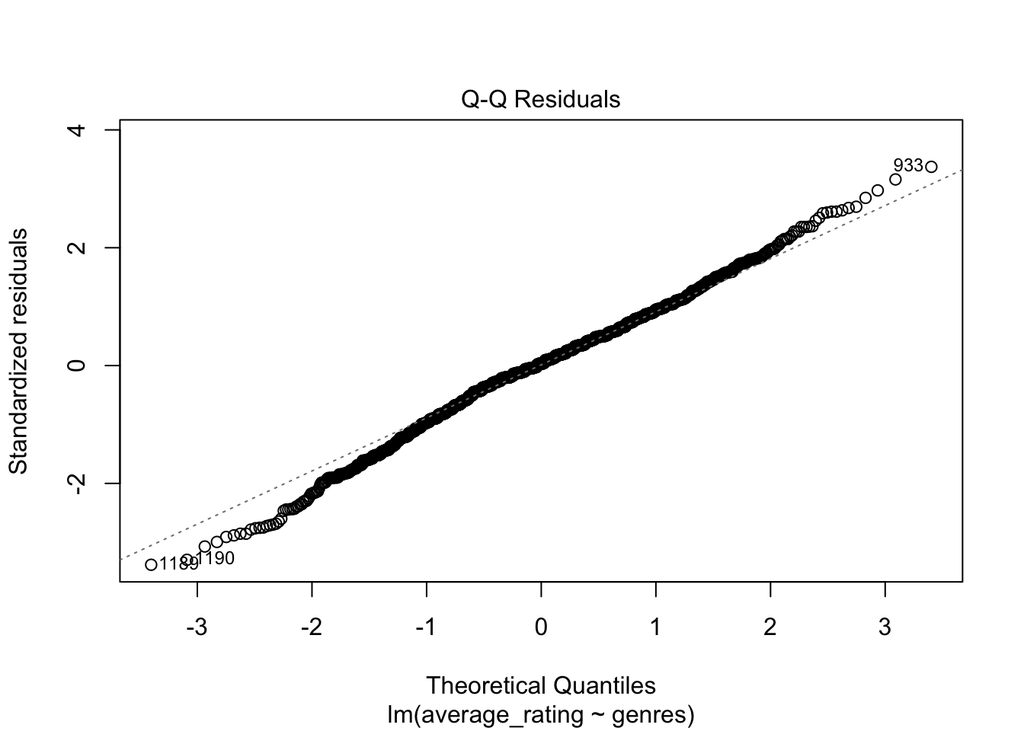

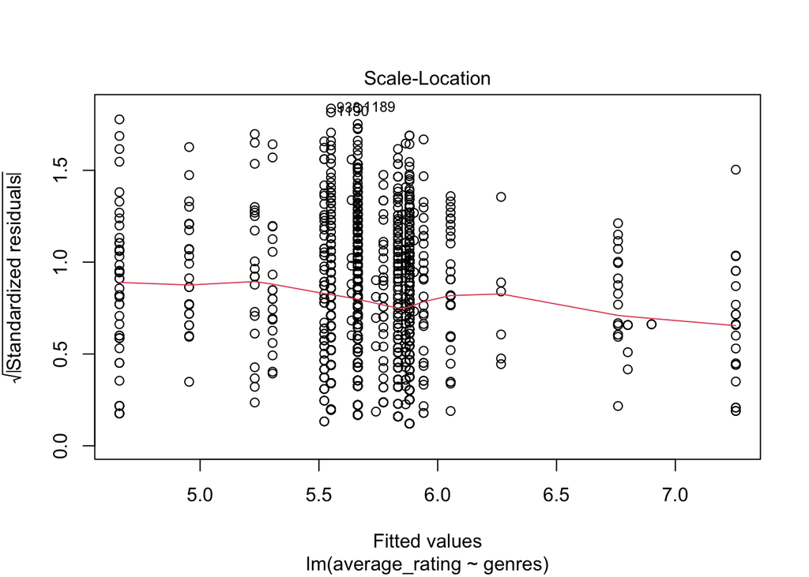

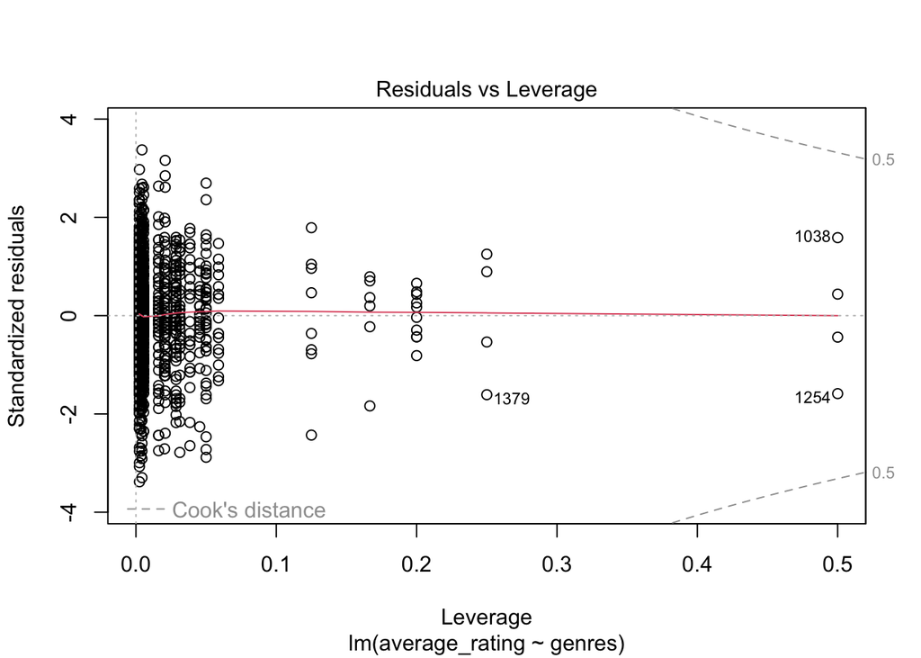

```r
plot(M1)
```

```r
tar_load(M2)
summary(M2)
```

```
Call:
lm(formula = average_rating ~ genres + christmas, data = m_data)

Residuals:
    Min      1Q  Median      3Q     Max
-4.2313 -0.7404  0.0432  0.7991  4.3991

Coefficients:
                  Estimate Std. Error t value Pr(>|t|)
(Intercept)        5.54682    0.29017  19.116  < 2e-16 ***
genresAdventure    0.71638    0.33902   2.113 0.034759 *
genresAnimation    0.98095    0.35878   2.734 0.006329 **
genresBiography    1.64311    0.63844   2.574 0.010160 *
genresComedy       0.47187    0.29255   1.613 0.106971
genresCrime        0.40565    0.35855   1.131 0.258084
genresDocumentary  2.04005    0.39444   5.172 2.63e-07 ***
genresDrama        0.69735    0.29552   2.360 0.018415 *
genresFamily       0.44146    0.29808   1.481 0.138813
genresFantasy      0.42387    0.32901   1.288 0.197832
genresFilm-Noir    1.59689    0.94687   1.686 0.091912 .
genresHistory      0.59689    0.69936   0.853 0.393530
genresHorror      -0.44976    0.34034  -1.321 0.186544
genresMusic        1.52739    0.42115   3.627 0.000297 ***
genresMusical      0.65274    0.36403   1.793 0.073158 .
genresMystery      0.02626    0.40379   0.065 0.948159
genresRomance      0.63222    0.30070   2.102 0.035681 *
genresSci-Fi       0.51717    0.53437   0.968 0.333295
genresSport        0.79059    0.94721   0.835 0.404044
genresThriller    -0.25553    0.37972  -0.673 0.501089
genresWar          1.12603    0.59443   1.894 0.058382 .
genresWestern      0.48563    0.63834   0.761 0.446917
christmasTRUE     -0.48741    0.08000  -6.093 1.41e-09 ***
---
Signif. codes:  0 '***' 0.001 '**' 0.01 '*' 0.05 '.' 0.1 ' ' 1

Residual standard error: 1.277 on 1476 degrees of freedom
Multiple R-squared:  0.09253,   Adjusted R-squared:  0.07901
F-statistic: 6.841 on 22 and 1476 DF,  p-value: < 2.2e-16
```

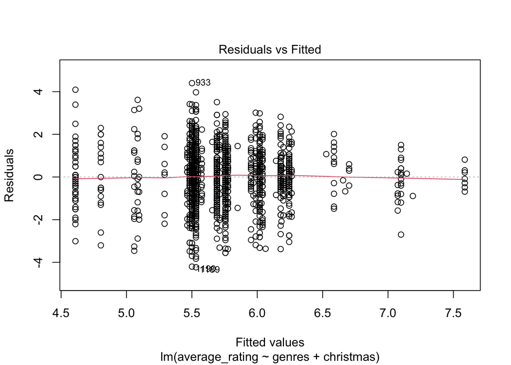

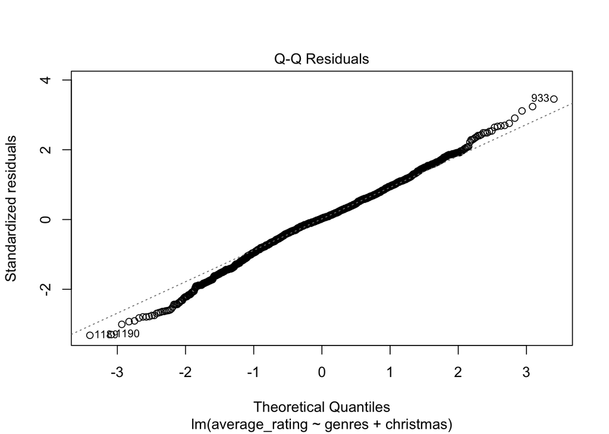

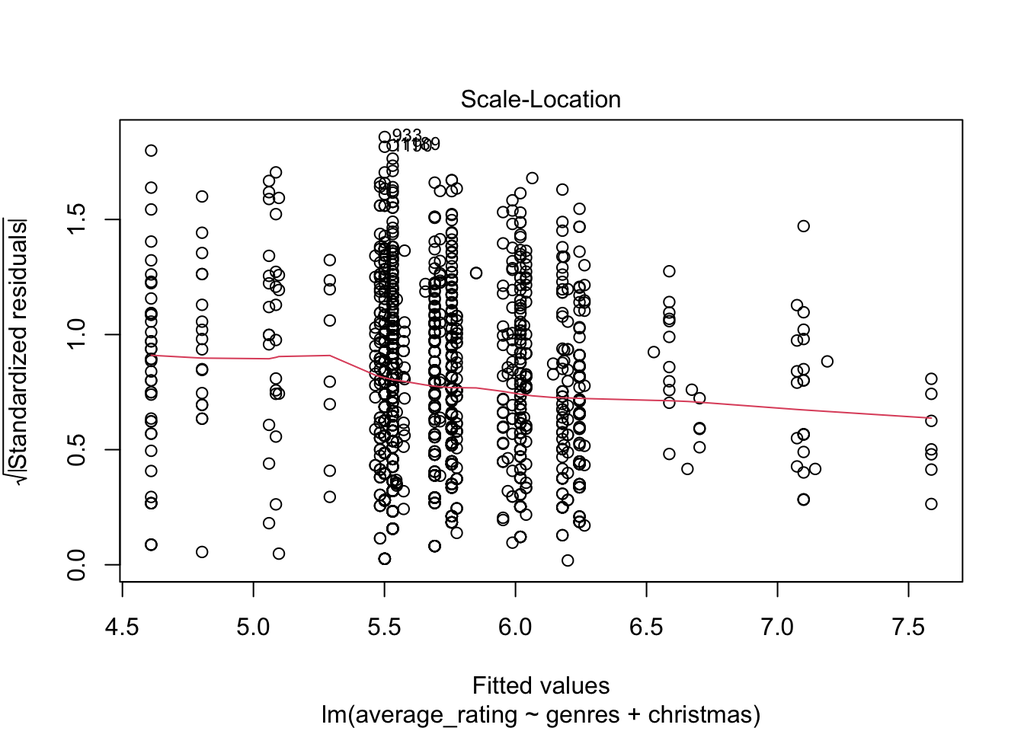

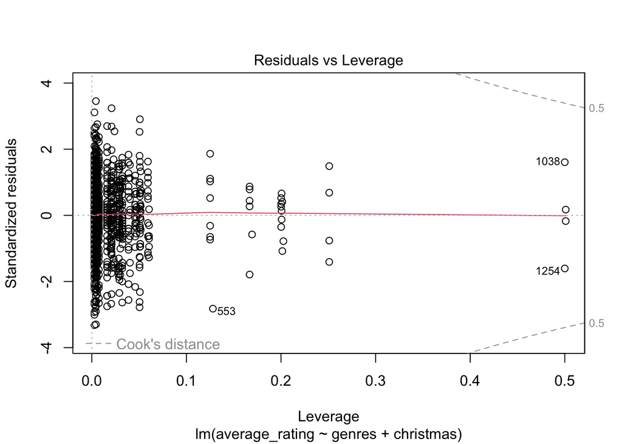

```r
plot(M2)
```

```r
tar_load(M3)
summary(M3)
```

```
Call:
lm(formula = average_rating ~ genres * christmas, data = m_data)

Residuals:
    Min      1Q  Median      3Q     Max
-4.2020 -0.7088  0.0162  0.7980  4.4233

Coefficients: (1 not defined because of singularities)
                                Estimate Std. Error t value Pr(>|t|)
(Intercept)                      6.01429    0.48269  12.460  < 2e-16 ***
genresAdventure                  0.43016    0.64359   0.668  0.50400
genresAnimation                  1.58571    1.36526   1.161  0.24564
genresBiography                  0.28571    1.36526   0.209  0.83426
genresComedy                     0.08296    0.49795   0.167  0.86770
genresCrime                      0.04935    0.55419   0.089  0.92905
genresDocumentary                1.54286    0.68263   2.260  0.02396 *
genresDrama                      0.18155    0.50561   0.359  0.71960
genresFamily                     0.18571    0.54859   0.339  0.73501
genresFantasy                   -0.31429    0.74778  -0.420  0.67434
genresFilm-Noir                  1.28571    1.36526   0.942  0.34648
genresHistory                    0.08571    1.02394   0.084  0.93330
genresHorror                    -1.17429    0.74778  -1.570  0.11655
genresMusic                      0.30238    0.71050   0.426  0.67047
genresMusical                   -0.07429    0.58457  -0.127  0.89890
genresMystery                   -0.68095    0.64359  -1.058  0.29021
genresRomance                    0.18383    0.51358   0.358  0.72044
genresSci-Fi                    -3.31429    1.36526  -2.428  0.01532 *
genresSport                      1.04231    0.97001   1.075  0.28276
genresThriller                  -0.78929    0.66095  -1.194  0.23261
genresWar                       -0.01429    1.36526  -0.010  0.99165
genresWestern                   -0.36429    1.02394  -0.356  0.72207
christmasTRUE                   -1.20659    0.59871  -2.015  0.04405 *
genresAdventure:christmasTRUE    0.49715    0.76186   0.653  0.51415
genresAnimation:christmasTRUE   -0.38458    1.42736  -0.269  0.78763
genresBiography:christmasTRUE    1.83159    1.54826   1.183  0.23700
genresComedy:christmasTRUE       0.61139    0.61561   0.993  0.32080
genresCrime:christmasTRUE        0.41988    0.74702   0.562  0.57415
genresDocumentary:christmasTRUE  0.76278    0.83676   0.912  0.36213
genresDrama:christmasTRUE        0.78409    0.62359   1.257  0.20882
genresFamily:christmasTRUE       0.48326    0.65892   0.733  0.46342
genresFantasy:christmasTRUE      1.01361    0.84454   1.200  0.23026
genresFilm-Noir:christmasTRUE    0.40659    1.90272   0.214  0.83082
genresHistory:christmasTRUE      0.80659    1.41046   0.572  0.56750
genresHorror:christmasTRUE       1.00613    0.85004   1.184  0.23675
genresMusic:christmasTRUE        1.88993    0.88235   2.142  0.03236 *
genresMusical:christmasTRUE      1.20777    0.75041   1.609  0.10773
genresMystery:christmasTRUE      1.15508    0.82942   1.393  0.16394
genresRomance:christmasTRUE      0.69233    0.63385   1.092  0.27490
genresSci-Fi:christmasTRUE       4.56374    1.49076   3.061  0.00224 **
genresSport:christmasTRUE             NA         NA      NA       NA
genresThriller:christmasTRUE     0.81493    0.80804   1.009  0.31337
genresWar:christmasTRUE          1.52659    1.52170   1.003  0.31592
genresWestern:christmasTRUE      1.35659    1.31056   1.035  0.30078
---
Signif. codes:  0 '***' 0.001 '**' 0.01 '*' 0.05 '.' 0.1 ' ' 1

Residual standard error: 1.277 on 1456 degrees of freedom
Multiple R-squared:  0.1042,    Adjusted R-squared:  0.07839
F-statistic: 4.034 on 42 and 1456 DF,  p-value: 4.507e-16
```

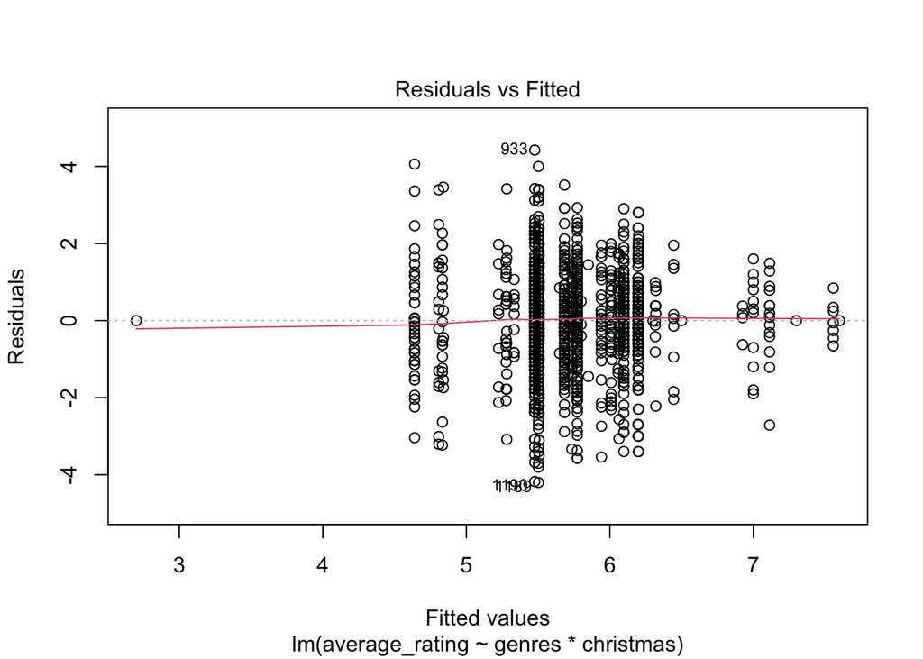

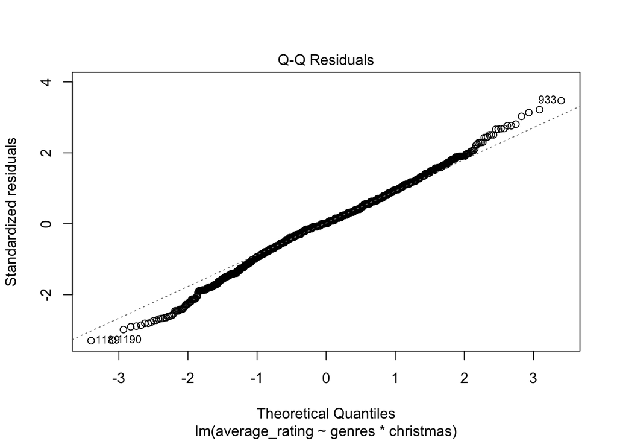

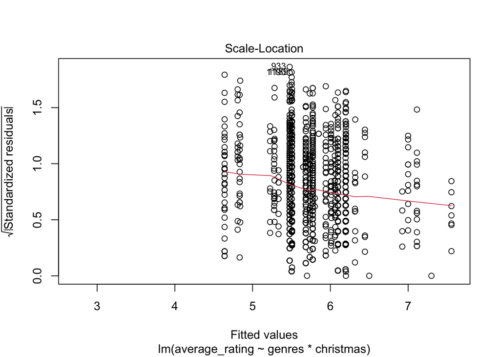

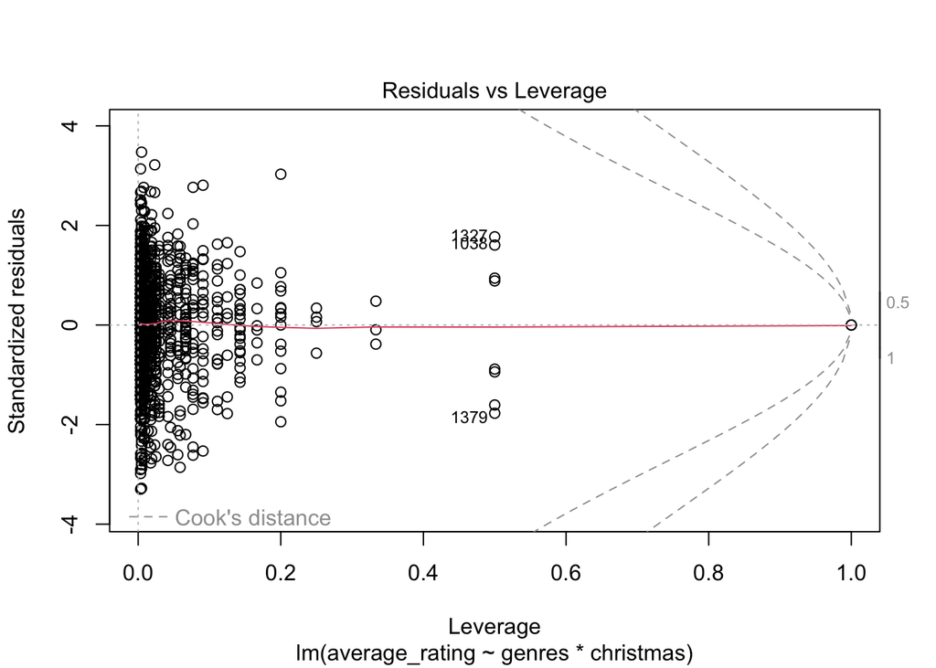

```r
plot(M3)
```

Since the response ‘average_values’ was duplicated in order to split the genres in ‘movies_clean’, there is perfect correlation between the duplicated datapoints. Hence, the assumption of independence between errors is not valid across the models and the results may be misleading. It would be more appropriate to fit a separate intercept for each movie in a mixed-effects model but, due to the low sample size of genres for each movie, it is unlikely that the model would converge fully and produce useful results.

Proceeding regardless, the four linear models (including the null model) can be compared using Aikake’s information criterion as follows.

```r
tar_read(movies_AIC)
```

```
# A tibble: 4 × 2
     df   AIC
  <dbl> <dbl>
1     2 5113.
2    23 5046.
3    24 5011.
4    44 5032.
```

Model M2 is preferred, since it minimises AIC (which corresponds to maximising likelihood while preventing overfitting). From the summary output for M2, we can see that Christmas movies reduce the average_rating of all movies by $\approx -0.49$, regardless of genre. According to this model, the best rated non-Christmas movie is a Documentary with an estimated rating of $\approx 7.59$. So, the best rated Christmas movie is also a Documentary but with an estimated rating of $\approx 7.1$. The second and third best rated Christmas movie genres are Biography and Film-Noir with estimated ratings of $\approx 6.7$ and $\approx 6.66$, respectively.

We can test whether the interaction term between Christmas and genres is statistically significant. Since $p=0.5215>0.05$, we retain the null hypothesis that genres’ effects on average_rating are not determined by whether or not the movie is a Christmas movie, at the 5% level of significance.

```r
tar_read(christmas_anova)
```

```
# A tibble: 2 × 6
  Res.Df   RSS    Df `Sum of Sq`      F `Pr(>F)`
   <dbl> <dbl> <dbl>       <dbl>  <dbl>    <dbl>
1   1476 2406.    NA        NA   NA       NA
2   1456 2375.    20        31.0  0.951    0.521
```